# **DS220: Project 2**

Data Analysis with Python Pandas by Hanna Oh

## Part 1: Introduction

In this Jupyter Notebook, I analyzed the **"Netflix Movies and TV Shows"** dataset from Kaggle, which provides information about content available on Netflix as of 2021. The data includes key features such as title, director, cast, country, release year, genre, and date added to the platform. This data offers insight into trends such as content distribution across countries, genre popularity, and how Netflix’s content has evolved over time.

The main objective of this project is to explore patterns and trends within the Netflix catalog using data visualization and basic statistics. The steps include loading the data, cleaning, conducting exploratory analysis, and drawing conclusions. To perform the analysis, I used Python libraries such as pandas, numpy, matplotlib, and seaborn.

This dataset has 12 columns and 8,807 rows, representing individual movies and TV shows available on Netflix.

1. show_id
2. type (Movie or TV Show)
3. title
4. director
5. cast
6. country
7. date_added
8. release_year
9. rating
10. duration
11. listed_in (Genre)
12. description

### Importing the Libraries & Loading the Dataset

I impoted the necessary libraries to support data loading, cleaning, and visualization. The dataset contains 8807 rows and 12 columns.

```python
import pandas as pd
import numpy as np
import matplotlib.pyplot as plt
import seaborn as sns
import warnings
warnings.filterwarnings('ignore')

df = pd.read_csv('netflix_titles.csv')
df
```

|  | show_id | type | title | director | cast | country | date_added | release_year | rating | duration | listed_in | description |
| --- | --- | --- | --- | --- | --- | --- | --- | --- | --- | --- | --- | --- |
| 0 | s1 | Movie | Dick Johnson Is Dead | Kirsten Johnson | NaN | United States | September 25, 2021 | 2020 | PG-13 | 90 min | Documentaries | As her father nears the end of his life, filmm... |
| 1 | s2 | TV Show | Blood & Water | NaN | Ama Qamata, Khosi Ngema, Gail Mabalane, Thaban... | South Africa | September 24, 2021 | 2021 | TV-MA | 2 Seasons | International TV Shows, TV Dramas, TV Mysteries | After crossing paths at a party, a Cape Town t... |
| 2 | s3 | TV Show | Ganglands | Julien Leclercq | Sami Bouajila, Tracy Gotoas, Samuel Jouy, Nabi... | NaN | September 24, 2021 | 2021 | TV-MA | 1 Season | Crime TV Shows, International TV Shows, TV Act... | To protect his family from a powerful drug lor... |
| 3 | s4 | TV Show | Jailbirds New Orleans | NaN | NaN | NaN | September 24, 2021 | 2021 | TV-MA | 1 Season | Docuseries, Reality TV | Feuds, flirtations and toilet talk go down amo... |
| 4 | s5 | TV Show | Kota Factory | NaN | Mayur More, Jitendra Kumar, Ranjan Raj, Alam K... | India | September 24, 2021 | 2021 | TV-MA | 2 Seasons | International TV Shows, Romantic TV Shows, TV ... | In a city of coaching centers known to train I... |
| ... | ... | ... | ... | ... | ... | ... | ... | ... | ... | ... | ... | ... |
| 8802 | s8803 | Movie | Zodiac | David Fincher | Mark Ruffalo, Jake Gyllenhaal, Robert Downey J... | United States | November 20, 2019 | 2007 | R | 158 min | Cult Movies, Dramas, Thrillers | A political cartoonist, a crime reporter and a... |
| 8803 | s8804 | TV Show | Zombie Dumb | NaN | NaN | NaN | July 1, 2019 | 2018 | TV-Y7 | 2 Seasons | Kids' TV, Korean TV Shows, TV Comedies | While living alone in a spooky town, a young g... |
| 8804 | s8805 | Movie | Zombieland | Ruben Fleischer | Jesse Eisenberg, Woody Harrelson, Emma Stone, ... | United States | November 1, 2019 | 2009 | R | 88 min | Comedies, Horror Movies | Looking to survive in a world taken over by zo... |
| 8805 | s8806 | Movie | Zoom | Peter Hewitt | Tim Allen, Courteney Cox, Chevy Chase, Kate Ma... | United States | January 11, 2020 | 2006 | PG | 88 min | Children & Family Movies, Comedies | Dragged from civilian life, a former superhero... |
| 8806 | s8807 | Movie | Zubaan | Mozez Singh | Vicky Kaushal, Sarah-Jane Dias, Raaghav Chanan... | India | March 2, 2019 | 2015 | TV-14 | 111 min | Dramas, International Movies, Music & Musicals | A scrappy but poor boy worms his way into a ty... |

8807 rows × 12 columns

## Part 2: Exploratory Data Analysis

Before analysis, I explored the basic structure and quality of the dataset.

```python
df.info() #check data types and non-null values
```

```
<class 'pandas.core.frame.DataFrame'>
RangeIndex: 8807 entries, 0 to 8806
Data columns (total 12 columns):
 #   Column        Non-Null Count  Dtype
---  ------        --------------  -----
 0   show_id       8807 non-null   object
 1   type          8807 non-null   object
 2   title         8807 non-null   object
 3   director      6173 non-null   object
 4   cast          7982 non-null   object
 5   country       7976 non-null   object
 6   date_added    8797 non-null   object
 7   release_year  8807 non-null   int64
 8   rating        8803 non-null   object
 9   duration      8804 non-null   object
 10  listed_in     8807 non-null   object
 11  description   8807 non-null   object
dtypes: int64(1), object(11)
memory usage: 825.8+ KB
```

Expect release_year, all the columns are of the object type, which means that they include data in the form of string values. Also, it shows that some columns such as director, cast, and country have missing values (because they have fewer rows than the total number of rows).

```python
df.describe() #Return the statistics for the numerical columns present in the dataset
```

|  | release_year |
| --- | --- |
| count | 8807.000000 |
| mean | 2014.180198 |
| std | 8.819312 |
| min | 1925.000000 |
| 25% | 2013.000000 |
| 50% | 2017.000000 |
| 75% | 2019.000000 |
| max | 2021.000000 |

The dataset consists only one numerical column: release_year.

#### **2.1 Data Cleaning**

Since several solumns contain missing values, I will clean the data before visualization and modeling.

```python
df.isnull().sum() #check how many missing values each column has
```

```
show_id            0
type               0
title              0
director        2634
cast             825
country          831
date_added        10
release_year       0
rating             4
duration           3
listed_in          0
description        0
dtype: int64
```

As seen above, columns like director, cast, and country have a high number of missing vlaues. I may fill, drop, or ignore these columns.

```python
# Drop rows where 'type', 'title', or 'release_year' are missing
df.dropna(subset=['type', 'title', 'release_year'], inplace=True)

# Fill missing country values with the mode (most frequent country)
df['country'].fillna(df['country'].mode()[0], inplace=True)

# Fill missing director and cast with 'Unknown'
df['director'].fillna('Unknown', inplace=True)
df['cast'].fillna('Unknown', inplace=True)

# Fill missing date_added with a placeholder
df['date_added'].fillna('Unknown', inplace=True)
```

```python
# drop the remaining rows with nan values
df.dropna(inplace = True)
```

```python
# again check for the null values
df.isnull().sum()
```

```
show_id         0
type            0
title           0
director        0
cast            0
country         0
date_added      0
release_year    0
rating          0
duration        0
listed_in       0
description     0
dtype: int64
```

#### **2.2 Data Analysis and Visualizations**

**Question 1: How has the number of TV Shows and Movies released on Netflix changed over time?**

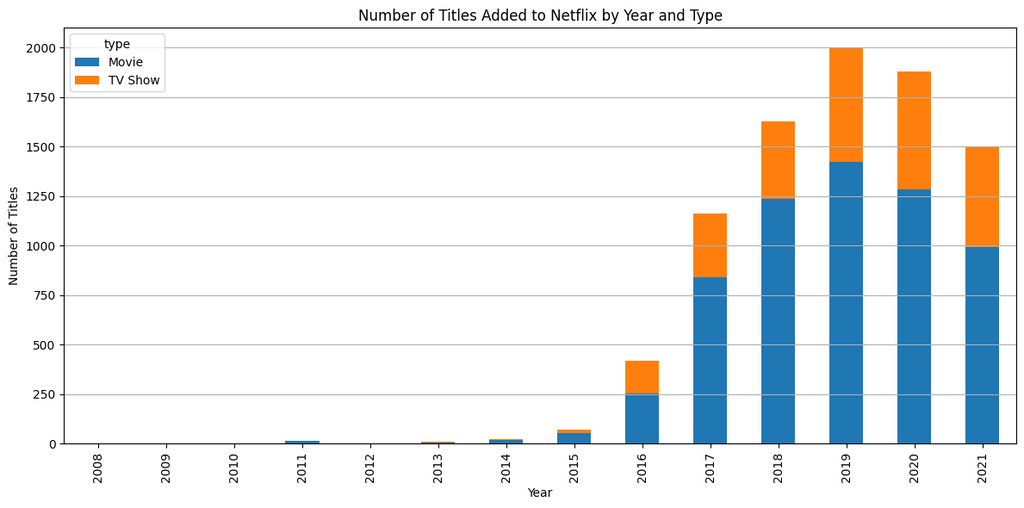

```python
df['date_added'] = pd.to_datetime(df['date_added'], errors='coerce')

df['year_added'] = df['date_added'].dt.year
df = df[df['year_added'].notna()]
df['year_added'] = df['year_added'].astype(int)

yearly_counts = df.groupby(['year_added', 'type']).size().unstack()
yearly_counts.plot(kind='bar', stacked=True, figsize=(12, 6))
plt.title('Number of Titles Added to Netflix by Year and Type')
plt.xlabel('Year')
plt.ylabel('Number of Titles')
plt.grid(axis='y')
plt.tight_layout()
plt.show()
```

The total number of titles added to Netflix has grown significantly in recent years (2017-2021). Movies dominate the catalog, although TV Shows have seen steady growth.

This shows that Netflix is focusing more on movie content to appeal to a broader audience, possibly as a strategy to compete in the global market.

**Question 2: Which countries produce the most Netflix conetent, and how has that changed over time?**

[figure not shown]

```python
top_countries = df['country'].value_counts().head(10).index

plt.figure(figsize=(10, 6))
sns.countplot(data=df[df['country'].isin(top_countries)], y='country', hue='type')
plt.title('Top 10 Countries Producing Netflix Content')
plt.xlabel('Count')
plt.ylabel('Country')
plt.legend(title='Type')
plt.tight_layout()
plt.show()
```

The United States dominates in terms of content production, followed by India and the United Kingdom.

This indicates Netflix's global content strategy and efforts to localize content for different regions.

**Question 3: What is the distribution of content rating by type (Movie vs TV Show)?**

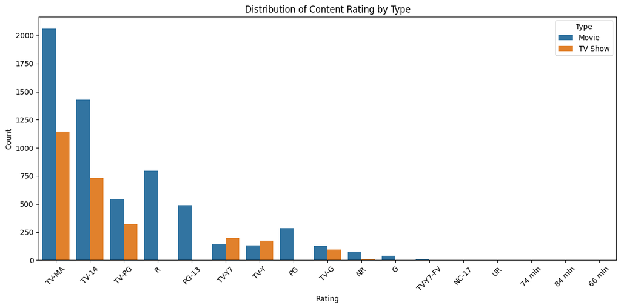

```python
plt.figure(figsize=(12, 6))
sns.countplot(data=df, x='rating', hue='type', order=df['rating'].value_counts().index)
plt.xticks(rotation=45)
plt.title('Distribution of Content Rating by Type')
plt.xlabel('Rating')
plt.ylabel('Count')
plt.legend(title='Type')
plt.tight_layout()
plt.show()
```

TV-MA is the most common rating across both movies and TV Shows. It means that there's a strong focus on mature audiences. While TV Shows tend to concentrate around a few ratings like TV-MA and TV-14, movies display a broader spread across R, PG-13, PG, and more.

This shows Neflix's intent to target both general and adult viewers with a versatile content strategy.

**Question 4: What genres are most commonly produced and how do they vary between movies and TV shows?**

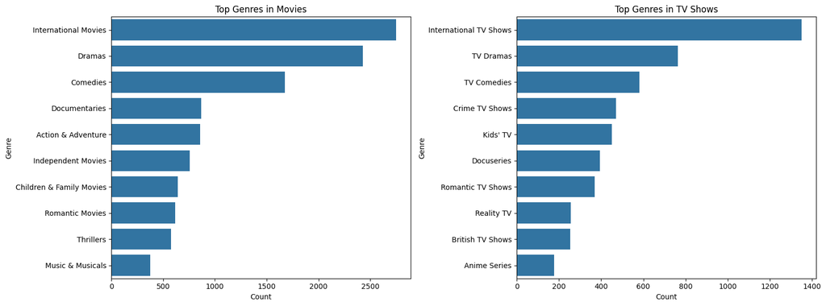

```python
from collections import Counter

def get_top_genres(df, content_type, n=10):
    genres = df[df['type'] == content_type]['listed_in'].str.split(', ')
    flat_list = [genre for sublist in genres for genre in sublist]
    return Counter(flat_list).most_common(n)

movie_genres = get_top_genres(df, 'Movie')
tv_genres = get_top_genres(df, 'TV Show')

movie_genres_df = pd.DataFrame(movie_genres, columns=['Genre', 'Count'])
tv_genres_df = pd.DataFrame(tv_genres, columns=['Genre', 'Count'])

fig, axes = plt.subplots(1, 2, figsize=(16, 6))
sns.barplot(data=movie_genres_df, y='Genre', x='Count', ax=axes[0])
axes[0].set_title('Top Genres in Movies')
sns.barplot(data=tv_genres_df, y='Genre', x='Count', ax=axes[1])
axes[1].set_title('Top Genres in TV Shows')
plt.tight_layout()
plt.show()
```

Both Movies and TV Shows focus heavily on International content, dramas, and comedies. TV shows have more content in Kids' Shows, Docuseries, and Reality TV, while movies lean toward Action & Adventure and Thrillers.

This shows how Netflix tailors genre offering by content type to suit viewer habits.

**Question 5: WHat is the distribution of movie durations on Netflix?**

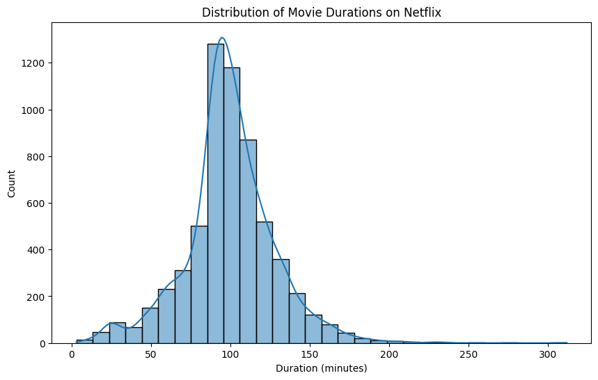

```python
df_movies = df[df['type'] == 'Movie']
df_movies['duration_num'] = df_movies['duration'].str.extract('(\d+)').astype(float)

plt.figure(figsize=(10,6))
sns.histplot(df_movies['duration_num'], bins=30, kde=True)
plt.title('Distribution of Movie Durations on Netflix')
plt.xlabel('Duration (minutes)')
plt.ylabel('Count')
plt.show()
```

Most movies are between 80 and 120 minutes, which aligns with standard feature film legnths. Very short films (< 60 min) and long-format films (> 150) are rare, reflecting a strategic avoidance of duration extremes.

This pattern shows that Netflix focuses on maintaining viewer attention and minimizing commitment barriers. By limiting movie duration, the platform ensures content is consumable in shorter time frames, ideal for binge-watching culture.

**Question 6: What are the most common combinations of director and genre? Do certain directors specialize in specific genres?**

[figure not shown]

```python
df_dir_genre = df[['director', 'listed_in']].dropna()
df_dir_genre['listed_in'] = df_dir_genre['listed_in'].str.split(', ')
df_dir_genre = df_dir_genre.explode('listed_in')

top_directors = df_dir_genre['director'].value_counts().head(10).index
filtered = df_dir_genre[df_dir_genre['director'].isin(top_directors)]

plt.figure(figsize=(12,8))
sns.countplot(data=filtered, y='director', hue='listed_in')
plt.title('Top 10 Directors and Their Preferred Genres')
plt.xlabel('Number of Titles')
plt.ylabel('Director')
plt.legend(title='Genre', bbox_to_anchor=(1.05, 1), loc='upper left')
plt.tight_layout()
plt.show()
```

Many directors consistently produce within a specific genre. For example, directors like Suhas Kadav heavily involved in Children & Family Movies, and Youssef Chahine invloved in Dramas.

It shows alignment of directors with content strategies for targeted audiences. This may be an Netflix's brand-building strategy, offering viewers consistent quality and theme expectations.

### Conclusion

Overall, Netflix is using a smart strategy to grow its platform. By offering a wide range of content in different formats and from many countries, Netflix can connect with many types of viewers around the world.